# 科技文献可视化期末作业

张杨燚 2019101458，彭子健 2019101455

# Note

**整个项目都放到了github上： https://github.com/pzjzeason/bib 。**在统计论文平均每年被引以及关键词突发检测这两个任务中，用到的是python的代码，python代码见`py.ipynb`(运行需要jupyter环境，或者直接在github仓库中查看)。

# 1 文献检索

**数据源**: Clarivate Analytics Web of Science (http://apps.webofknowledge.com)，选择“核心数据库”

**检索式**: （标题）TI = ( smart factory OR intelligent factory OR ubiquitous factory OR real-time factory OR smart factories OR smarter factories OR intelligent factories OR ubiquitous factories OR real-time factories OR smart manufacturing OR smarter manufacturing OR intelligent manufacturing OR ubiquitous manufacturing OR real-time manufacturing OR factory-of-things)) AND 语种: (English)

**时间区间**: 2007年-2016年5月（手动排除5月份之后的数据）

**文章类型**: 会议和论文

**检索日期**: 2019年11月29日

**导出格式**: Bibtex格式

# 2 导入数据并转换

```r
# 导入包
library(bibliometrix)
library(igraph)
library(knitr)
library(kableExtra)
library(data.table)

D <- readFiles('07-16.bib')
M <- convert2df(D, dbsource='isi', format='bibtex') # 利用convert2df转化
```

# 3 Citation Network Analysis

## 3.1 Overall Citation Network

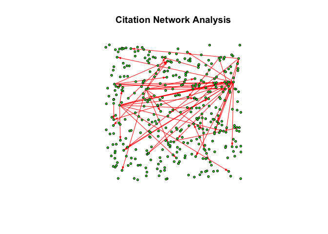

```r
# 文献互引网络
## function that reverses all edges in graph
graph.reverse <- function (graph) {
  if (!is.directed(graph))
    return(graph)
  e <- get.data.frame(graph, what="edges")
  ## swap "from" & "to"
  neworder <- 1:length(e)
  neworder[1:2] <- c(2,1)
  e <- e[neworder]
  names(e) <- names(e)[neworder]
  graph.data.frame(e, vertices = get.data.frame(graph, what="vertices"))
}

## use histNetwork in bibliometrix to compute citation
histResults  <- histNetwork(M, min.citations = 0,sep = ";")
citationGraph <- graph.reverse(graph_from_adjacency_matrix(histResults$NetMatrix, mode="directed", weighted=NULL, diag= FALSE))
splitNames=strsplit(names(V(citationGraph)),",")
nameAndYear=lapply(splitNames,
  function(l){
    l=l[1:2]
    l=paste(strsplit(l[1],' ')[[1]][1],'(',l[2],')', sep='')
})
V(citationGraph)$lab <- tolower(unlist(nameAndYear))

## plot
plot.igraph(citationGraph,
            vertex.label=NA,
            vertex.color= "green",
            vertex.size=3,
            vertex.label.cex=0.8,
            edge.color="red",
            edge.arrow.size=0.3,
            edge.arrow.width=1,
            layout=layout_randomly,
            main="Citation Network Analysis")
```

## 3.2 Top 3 biggest connected components

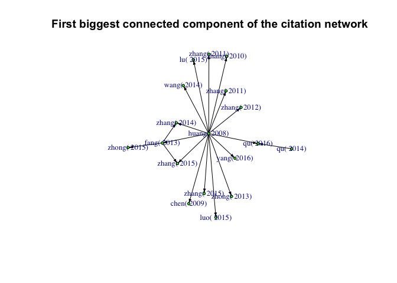

```r
singlePoints = which(degree(citationGraph)==0)
connectGraph = delete.vertices(citationGraph, singlePoints)
cps = components(connectGraph,mode='weak')
plotCompoent = function(index) {
    rankstr = c('First','Second', 'Third')
    cluster = which(cps$csize == sort(cps$csize, decreasing = TRUE)[index])
    g = induced_subgraph(citationGraph,
                     vids=names(cps$membership)[which(cps$membership==cluster)]
                     )
    plot.igraph(g,
            vertex.label = V(g)$lab,
            vertex.color= "green",
            vertex.size=3,
            vertex.label.cex=0.8,
            edge.color="black",
            edge.arrow.size=0.3,
            edge.arrow.width=1,
            layout=layout.fruchterman.reingold,
            main=paste(rankstr[index], "biggest connected component of the citation network"))
}

# first
plotCompoent(1)
```

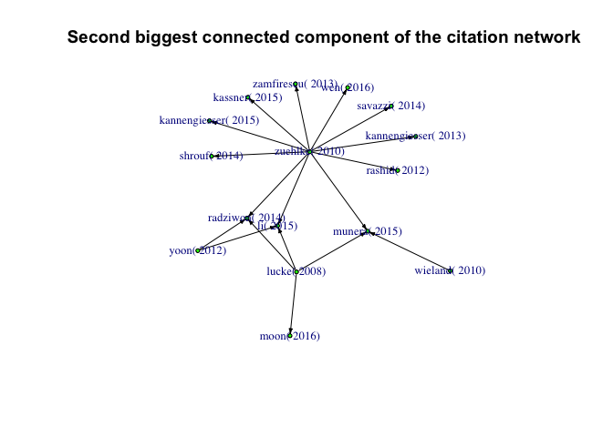

```r
# second
plotCompoent(2)
```

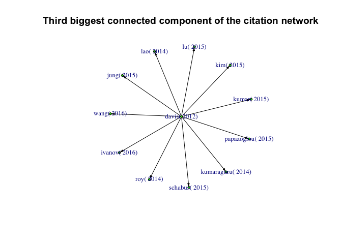

```r
# third
plotCompoent(3)
```

# 4 全局/局部被引分析

```r
# 被引统计
citationCount <- localCitations(M, sep=';')$Papers
dt1 <- data.table(citationCount, key = "Paper")
dt2 <- data.table(M, key = "SR")
citationCountMerge <- dt1[dt2][,c('TI','AU','SO','Year','GCS', 'LCS')]
colnames(citationCountMerge) <- c('Title', 'Author', 'Journal', 'Year', 'GCS', 'LCS')
```

## 4.1 局部被引top 10

```r
# 局部被引top10
LCS_top_10 = data.frame(
    Rank=c(1:10),
    citationCountMerge[order(citationCountMerge$LCS,decreasing = TRUE),][c(1:10),],
    row.names=NULL
)
kable(LCS_top_10,caption = "LCS Top 10")%>%
  kable_styling(bootstrap_options = c("striped", "hover", "condensed", "responsive"), full_width = F)
```

LCS Top 10

| Rank | Title | Author | Journal | Year | GCS | LCS |
| --- | --- | --- | --- | --- | --- | --- |
| 1 | RFID-ENABLED REAL-TIME WIRELESS MANUFACTURING FOR ADAPTIVE ASSEMBLY PLANNING AND CONTROL | HUANG GQ;ZHANG YF;CHEN X;NEWMAN ST | JOURNAL OF INTELLIGENT MANUFACTURING | 2008 | 83 | 16 |
| 2 | SMART MANUFACTURING, MANUFACTURING INTELLIGENCE AND DEMAND-DYNAMIC PERFORMANCE | DAVIS J;EDGAR T;PORTER J;BERNADEN J;SARLI M | COMPUTERS &amp; CHEMICAL ENGINEERING | 2012 | 193 | 11 |
| 3 | SMARTFACTORY-TOWARDS A FACTORY-OF-THINGS | ZUEHLKE D | ANNUAL REVIEWS IN CONTROL | 2010 | 232 | 11 |
| 4 | SMART FACTORY - A STEP TOWARDS THE NEXT GENERATION OF MANUFACTURING | LUCKE D;CONSTANTINESCU C;WESTKAEMPER E | MANUFACTURING SYSTEMS AND TECHNOLOGIES FOR THE NEW FRONTIER | 2008 | 94 | 7 |
| 5 | EVENT-DRIVEN MULTI-AGENT UBIQUITOUS MANUFACTURING EXECUTION PLATFORM FOR SHOP FLOOR WORK-IN-PROGRESS MANAGEMENT | FANG J;HUANG GQ;LI Z | INTERNATIONAL JOURNAL OF PRODUCTION RESEARCH | 2013 | 27 | 3 |
| 6 | A HYBRID INTELLIGENT MODEL FOR ORDER ALLOCATION PLANNING IN MAKE-TO-ORDER MANUFACTURING | GUO ZX;WONG WK;LEUNG SYS | APPLIED SOFT COMPUTING | 2013 | 15 | 2 |
| 7 | A CONCEPTUAL FRAMEWORK FOR THE UBIQUITOUS FACTORY | YOON JS;SHIN SJ;SUH SH | INTERNATIONAL JOURNAL OF PRODUCTION RESEARCH | 2012 | 31 | 2 |
| 8 | DISTRIBUTED MANUFACTURING CONTROL WITH EXTENDED CNP INTERACTION OF INTELLIGENT PRODUCTS | BORANGIU T;RAILEANU S;TRENTESAUX D;BERGER T;IACOB I | JOURNAL OF INTELLIGENT MANUFACTURING | 2014 | 27 | 1 |
| 9 | MODELING THE THERMAL BEHAVIOR OF PZT PATCHES DURING THE MANUFACTURING PROCESS OF SMART THERMOPLASTIC STRUCTURES | ELSOUFI L;KHALIL K;LACHAT R;CHARON W | SMART MATERIALS &amp; STRUCTURES | 2007 | 5 | 1 |
| 10 | MONITORING TEA FERMENTATION/MANUFACTURING BY DIRECT ANALYSIS IN REAL TIME (DART) MASS SPECTROMETRY | FRASER K;LANE GA;OTTER DE;HARRISON SJ;QUEK SY;HEMAR Y;RASMUSSEN S | FOOD CHEMISTRY | 2013 | 24 | 1 |

## 4.2 全局被引被引top 10

```r
# 全局被引被引top10
GCS_top_10 = data.frame(
    Rank=c(1:10),
    citationCountMerge[order(citationCountMerge$GCS,decreasing = TRUE),][c(1:10),],
    row.names=NULL
)
kable(GCS_top_10,caption = "GCS Top 10") %>%
  kable_styling(bootstrap_options = c("striped", "hover", "condensed", "responsive"), full_width = F)
```

GCS Top 10

| Rank | Title | Author | Journal | Year | GCS | LCS |
| --- | --- | --- | --- | --- | --- | --- |
| 1 | IMPLEMENTING SMART FACTORY OF INDUSTRIE 4.0: AN OUTLOOK | WANG S;WAN J;LI D;ZHANG C | INTERNATIONAL JOURNAL OF DISTRIBUTED SENSOR NETWORKS | 2016 | 425 | 0 |
| 2 | IOT-BASED INTELLIGENT PERCEPTION AND ACCESS OF MANUFACTURING RESOURCE TOWARD CLOUD MANUFACTURING | TAO F;ZUO Y;XU LD;ZHANG L | IEEE TRANSACTIONS ON INDUSTRIAL INFORMATICS | 2014 | 256 | 0 |
| 3 | SMARTFACTORY-TOWARDS A FACTORY-OF-THINGS | ZUEHLKE D | ANNUAL REVIEWS IN CONTROL | 2010 | 232 | 11 |
| 4 | RFID-ENABLED REAL-TIME MANUFACTURING EXECUTION SYSTEM FOR MASS-CUSTOMIZATION PRODUCTION | ZHONG RY;DAI QY;QU T;HU GJ;HUANG GQ | ROBOTICS AND COMPUTER-INTEGRATED MANUFACTURING | 2013 | 203 | 0 |
| 5 | SMART MANUFACTURING, MANUFACTURING INTELLIGENCE AND DEMAND-DYNAMIC PERFORMANCE | DAVIS J;EDGAR T;PORTER J;BERNADEN J;SARLI M | COMPUTERS &amp; CHEMICAL ENGINEERING | 2012 | 193 | 11 |
| 6 | SMART FACTORIES IN INDUSTRY 4.0: A REVIEW OF THE CONCEPT AND OF ENERGY MANAGEMENT APPROACHED IN PRODUCTION BASED ON THE INTERNET OF THINGS PARADIGM | SHROUF F;ORDIERES J;MIRAGLIOTTA G | 2014 IEEE INTERNATIONAL CONFERENCE ON INDUSTRIAL ENGINEERING AND ENGINEERING MANAGEMENT (IEEM) | 2014 | 154 | 0 |
| 7 | RFID-BASED WIRELESS MANUFACTURING FOR REAL-TIME MANAGEMENT OF JOB SHOP WIP INVENTORIES | HUANG GQ;ZHANG YF;JIANG PY | INTERNATIONAL JOURNAL OF ADVANCED MANUFACTURING TECHNOLOGY | 2008 | 119 | 0 |
| 8 | A DYNAMIC MODEL AND AN ALGORITHM FOR SHORT-TERM SUPPLY CHAIN SCHEDULING IN THE SMART FACTORY INDUSTRY 4.0 | IVANOV D;DOLGUI A;SOKOLOV B;WERNER F;IVANOVA M | INTERNATIONAL JOURNAL OF PRODUCTION RESEARCH | 2016 | 104 | 0 |
| 9 | AN AGENT-BASED SERVICE-ORIENTED INTEGRATION ARCHITECTURE FOR COLLABORATIVE INTELLIGENT MANUFACTURING | SHEN W;HAO Q;WANG S;LIA Y;GHENNIWA H | ROBOTICS AND COMPUTER-INTEGRATED MANUFACTURING | 2007 | 102 | 0 |
| 10 | REAL-TIME INFORMATION CAPTURING AND INTEGRATION FRAMEWORK OF THE INTERNET OF MANUFACTURING THINGS | ZHANG Y;ZHANG G;WANG J;SUN S;SI S;YANG T | INTERNATIONAL JOURNAL OF COMPUTER INTEGRATED MANUFACTURING | 2015 | 101 | 0 |

## 4.3 GCS Top 10: citation forward every year from WOS

```r
citedPerYear = read.csv('./cited-forward.csv', check.names=FALSE)
kable(head(citedPerYear, 10),caption = "Citation forward every year") %>%
  kable_styling(bootstrap_options = c("striped", "hover", "condensed", "responsive"), full_width = F)
```

Citation forward every year

| Rank | Title | Authors | Journal | Publication Year | GCS | 2007 | 2008 | 2009 | 2010 | 2011 | 2012 | 2013 | 2014 | 2015 | 2016 | CitedPerYear |
| --- | --- | --- | --- | --- | --- | --- | --- | --- | --- | --- | --- | --- | --- | --- | --- | --- |
| 1 | IOT-BASED INTELLIGENT PERCEPTION AND ACCESS OF MANUFACTURING RESOURCE TOWARD CLOUD MANUFACTURING | Tao, Fei; Zuo, Ying; Xu, Li Da; Zhang, Lin | IEEE TRANSACTIONS ON INDUSTRIAL INFORMATICS | 2014 | 79 | 0 | 0 | 0 | 0 | 0 | 0 | 0 | 6 | 9 | 64 | 26.333333 |
| 2 | RFID-ENABLED REAL-TIME MANUFACTURING EXECUTION SYSTEM FOR MASS-CUSTOMIZATION PRODUCTION | Zhong, Ray Y.; Dai, Q. Y.; Qu, T.; Hu, G. J.; Huang, George Q. | ROBOTICS AND COMPUTER-INTEGRATED MANUFACTURING | 2013 | 82 | 0 | 0 | 0 | 0 | 0 | 0 | 5 | 18 | 28 | 31 | 20.500000 |
| 3 | IMPLEMENTING SMART FACTORY OF INDUSTRIE 4.0: AN OUTLOOK | Wang, Shiyong; Wan, Jiafu; Li, Di; Zhang, Chunhua | INTERNATIONAL JOURNAL OF DISTRIBUTED SENSOR NETWORKS | 2016 | 20 | 0 | 0 | 0 | 0 | 0 | 0 | 0 | 0 | 0 | 20 | 20.000000 |
| 4 | SMARTFACTORY-TOWARDS A FACTORY-OF-THINGS | Zuehlke, Detlef | ANNUAL REVIEWS IN CONTROL | 2010 | 100 | 0 | 0 | 0 | 1 | 7 | 8 | 20 | 9 | 25 | 30 | 14.285714 |
| 5 | TOWARDS SMART FACTORY FOR INDUSTRY 4.0: A SELF-ORGANIZED MULTI-AGENT SYSTEM WITH BIG DATA BASED FEEDBACK AND COORDINATION | Wang, Shiyong; Wan, Jiafu; Zhang, Daqiang; Li, Di; Zhang, Chunhua | COMPUTER NETWORKS | 2016 | 12 | 0 | 0 | 0 | 0 | 0 | 0 | 0 | 0 | 0 | 12 | 12.000000 |
| 6 | REAL-TIME INFORMATION CAPTURING AND INTEGRATION FRAMEWORK OF THE INTERNET OF MANUFACTURING THINGS | Zhang, Yingfeng; Zhang, Geng; Wang, Junqiang; Sun, Shudong; Si, Shubin; Yang, Teng | INTERNATIONAL JOURNAL OF COMPUTER INTEGRATED MANUFACTURING | 2015 | 22 | 0 | 0 | 0 | 0 | 0 | 0 | 0 | 1 | 8 | 13 | 11.000000 |
| 7 | SMART MANUFACTURING, MANUFACTURING INTELLIGENCE AND DEMAND-DYNAMIC PERFORMANCE | Davis, Jim; Edgar, Thomas; Porter, James; Bernaden, John; Sarli, Michael | COMPUTERS & CHEMICAL ENGINEERING | 2012 | 54 | 0 | 0 | 0 | 0 | 0 | 0 | 0 | 8 | 19 | 27 | 10.800000 |
| 8 | RFID-BASED WIRELESS MANUFACTURING FOR REAL-TIME MANAGEMENT OF JOB SHOP WIP INVENTORIES | Huang, George Q.; Zhang, Y. F.; Jiang, P. Y. | INTERNATIONAL JOURNAL OF ADVANCED MANUFACTURING TECHNOLOGY | 2008 | 85 | 0 | 0 | 8 | 9 | 10 | 15 | 11 | 8 | 14 | 10 | 9.444444 |
| 9 | AN AGENT-BASED SERVICE-ORIENTED INTEGRATION ARCHITECTURE FOR COLLABORATIVE INTELLIGENT MANUFACTURING | Shen, Welming; Hao, Qi; Wang, Shuying; Lia, Yinsheng; Ghenniwa, Hamada | ROBOTICS AND COMPUTER-INTEGRATED MANUFACTURING | 2007 | 84 | 1 | 14 | 10 | 10 | 11 | 9 | 4 | 4 | 15 | 6 | 8.400000 |
| 10 | A DYNAMIC MODEL AND AN ALGORITHM FOR SHORT-TERM SUPPLY CHAIN SCHEDULING IN THE SMART FACTORY INDUSTRY 4.0 | Ivanov, Dmitry; Dolgui, Alexandre; Sokolov, Boris; Werner, Frank; Ivanova, Marina | INTERNATIONAL JOURNAL OF PRODUCTION RESEARCH | 2016 | 7 | 0 | 0 | 0 | 0 | 0 | 0 | 0 | 0 | 0 | 7 | 7.000000 |

# 5 作者关键词网络分析

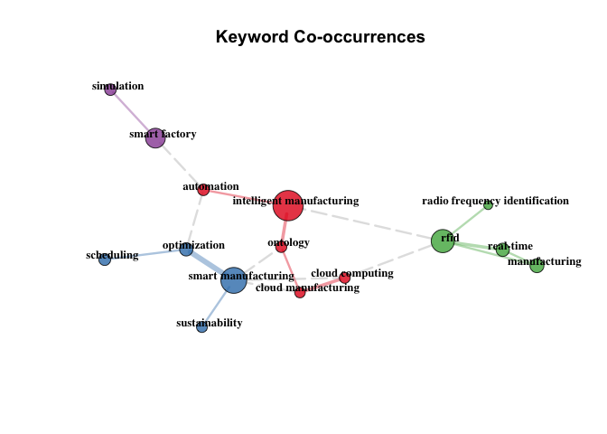

```r
# 构建关键词共现网络
coOccNet <- biblioNetwork(M, analysis = "co-occurrences", network = "author_keywords", sep = ";")
# 绘图
net = networkPlot(coOccNet, normalize="inclusion", weighted=T, n = 16, Title = "Keyword Co-occurrences", type = "fruchterman", size= 14, size.cex= T, edgesize = 6,labelsize=0.8, remove.isolates = TRUE, alpha = 0.8)
```

# 6 burst detection

这部分比较难，涉及了Kleinberg’s Burst算法，我们对此并不熟悉。于是找了实现这个算法的R包`burst`，但是文档说明不够清晰，并且这个实现版本适于连续型数值，而关键词的时间点是以年为单位。这部分我们做了一下的工作： 1. 按照论文的方式，检索1995～2016符合检索式的文献共1141篇，导出bibtex格式 2. 统计每年出现的关键词 3. 对关键词做stemming操作，并计算其频数 4. 尝试用python的burst_detection包进行关键词的burst detection

## 6.1 关键词统计结果

关键词stem后按年计数的完整结果请查看`stem-keywords-by-year.json`,每一年的top20关键词及其频数结果在`keywords-freq-top20.csv`。论文图-8中的关键词的每年频数在`keywords-freq.csv`。 这里我们`keywords-freq-top20.csv`和`selected-keywords-freq.csv`打印出来：

```r
top20 = read.csv('./keywords-freq-top20.csv', check.names=FALSE)
kable(top20,caption = "Top20 keywords frequency every year(1995~2016), scroll to see more") %>%
  kable_styling(bootstrap_options = c("striped", "hover", "condensed", "responsive"), full_width = F) %>%
  scroll_box(width = "100%", height = "fit-content")
```

Top20 keywords frequency every year(1995~2016), scroll to see more

| 1995 | 1996 | 1997 | 1998 | 1999 | 2000 | 2001 | 2002 | 2003 | 2004 | 2005 | 2006 | 2007 | 2008 | 2009 | 2010 | 2011 | 2012 | 2013 | 2014 | 2015 | 2016 |
| --- | --- | --- | --- | --- | --- | --- | --- | --- | --- | --- | --- | --- | --- | --- | --- | --- | --- | --- | --- | --- | --- |
| intellig,10 | intellig,3 | system,26 | system,14 | manufactur,11 | manufactur,20 | system,24 | system,14 | manufactur,14 | manufactur,23 | manufactur,12 | manufactur,15 | manufactur,15 | manufactur,33 | manufactur,26 | manufactur,22 | manufactur,24 | manufactur,34 | manufactur,33 | manufactur,42 | manufactur,68 | manufactur,78 |
| system,10 | manufactur,2 | manufactur,26 | manufactur,11 | system,8 | system,16 | manufactur,20 | manufactur,12 | system,13 | system,14 | system,11 | system,11 | system,11 | system,27 | intellig,19 | system,13 | system,16 | system,18 | system,16 | system,26 | system,53 | system,61 |
| manufactur,9 | neural,2 | intellig,22 | control,7 | intellig,8 | intellig,11 | control,13 | intellig,9 | intellig,8 | intellig,12 | control,4 | intellig,5 | control,10 | intellig,16 | system,18 | real-tim,12 | intellig,15 | intellig,10 | intellig,11 | intellig,22 | smart,32 | smart,43 |
| control,5 | network,2 | control,9 | intellig,5 | control,4 | control,9 | intellig,12 | control,7 | control,6 | control,10 | intellig,4 | network,5 | process,10 | control,10 | schedul,7 | intellig,7 | simul,9 | real-tim,7 | process,8 | process,18 | intellig,28 | product,35 |
| cell,3 | fuzzi,2 | artifici,8 | flexibl,4 | flexibl,3 | network,7 | network,9 | real-tim,5 | model,5 | schedul,5 | agent,4 | data,5 | intellig,6 | flexibl,7 | model,6 | rfid,6 | control,6 | monitor,7 | plan,7 | smart,17 | process,17 | factori,34 |
| integr,3 | logic,2 | network,8 | schedul,4 | neural,3 | schedul,6 | model,7 | agent,4 | simul,5 | simul,5 | integr,4 | factori,4 | real-tim,5 | product,6 | simul,6 | network,5 | process,5 | process,7 | real-tim,6 | factori,11 | control,16 | intellig,26 |
| engin,2 | object-ori,2 | neural,7 | network,3 | network,3 | neural,6 | fuzzi,7 | respons,3 | smart,5 | model,5 | schedul,4 | process,4 | model,5 | comput,6 | control,5 | agent,5 | time,4 | dynam,6 | schedul,6 | machin,9 | product,15 | industri,23 |
| expert,2 | configur,2 | fuzzi,6 | design,3 | the,3 | plan,5 | neural,5 | manag,3 | comput,5 | flexibl,5 | featur,4 | decis,4 | machin,5 | wireless,5 | real-tim,5 | control,5 | product,4 | manag,6 | product,6 | control,9 | model,14 | process,23 |
| robot,2 | autom,2 | agent,5 | simul,3 | simul,2 | agent,4 | process,4 | time,3 | real-tim,4 | product,4 | simul,3 | control,4 | design,4 | schedul,5 | agent,4 | enterpris,4 | real-tim,4 | design,5 | manag,6 | product,7 | design,12 | model,15 |
| plan,2 | system,2 | expert,4 | neural,2 | autom,2 | distribut,4 | agent,4 | schedul,2 | schedul,4 | sensor,4 | manag,3 | mine,4 | qualiti,4 | smart,5 | distribut,4 | wireless,4 | design,4 | enterpris,4 | machin,5 | manag,7 | factori,12 | energi,14 |
| process,2 | flexibl,1 | algorithm,4 | agent,2 | ``,2 | function,4 | support,4 | hybrid,2 | network,3 | real-tim,3 | model,3 | neural,3 | simul,3 | distribut,5 | multi-ag,4 | process,3 | machin,3 | rfid,4 | network,5 | thing,6 | machin,11 | control,12 |
| holon,1 | learn,1 | comput,4 | object-ori,2 | cell,2 | manag,3 | flexibl,4 | size,2 | agent,2 | process,3 | autom,3 | support,3 | network,3 | real-tim,5 | optim,4 | design,3 | agent,3 | flexibl,4 | control,5 | model,6 | optim,10 | internet,12 |
| work,1 | simul,1 | machin,4 | rule-bas,2 | floor,2 | dynam,3 | comput,3 | process,2 | time,2 | design,3 | real-tim,3 | plan,3 | sensor,3 | monitor,5 | process,4 | reconfigur,3 | model,3 | decis,4 | smart,4 | industri,6 | enterpris,10 | 4.0,11 |
| organ,1 | process,1 | engin,3 | mechan,2 | smart,2 | simul,3 | plan,3 | real,2 | configur,2 | rout,3 | time,2 | product,3 | statist,3 | manag,4 | efm,4 | digit,3 | multi-ag,3 | comput,4 | monitor,4 | decis,6 | monitor,9 | manag,11 |
| concurr,1 | control,1 | logic,3 | expert,2 | materi,1 | holon,3 | structur,3 | data,2 | card,2 | commun,3 | process,2 | schedul,3 | algorithm,3 | multi-ag,4 | oper,3 | schedul,3 | featur,3 | integr,4 | algorithm,4 | cloud,6 | schedul,9 | physic,11 |
| design,1 | mold,1 | monitor,3 | artifici,2 | hling,1 | multi-ag,3 | data,3 | distribut,2 | distribut,2 | artifici,2 | plan,2 | integr,3 | comput,3 | factori,4 | algorithm,3 | optim,3 | architectur,2 | sensor,4 | structur,4 | servic,6 | real-tim,9 | engin,10 |
| simul,1 | nonlinear,1 | process,3 | decis,2 | guid,1 | design,3 | simul,3 | flexibl,2 | holon,2 | network,2 | holon,2 | perform,2 | integr,3 | engin,4 | petri,3 | distribut,3 | optim,2 | model,4 | cloud,4 | engin,5 | network,9 | design,10 |
| knowledge-bas,1 | optim,1 | learn,3 | support,2 | vehicl,1 | comput,3 | multi-ag,3 | server,2 | function,2 | genet,2 | materi,2 | semiconductor,2 | flexibl,3 | object,3 | net,3 | product,3 | knowledg,2 | knowledg,4 | time,3 | autom,5 | cloud,9 | thing,10 |
| neural,1 | taguchi,1 | flexibl,3 | hybrid,2 | comput,1 | 3D,3 | decis,3 | decis,2 | effect,2 | algorithm,2 | hling,2 | case-bas,2 | smart,3 | execut,3 | knowledg,3 | comput,3 | supernova,2 | control,4 | architectur,3 | internet,5 | industri,9 | optim,9 |
| network,1 | method,1 | schedul,3 | process,2 | aid,1 | sensor,3 | real-tim,3 | information-loc,1 | autom,2 | materi,2 | recognit,2 | reason,2 | schedul,3 | autom,3 | machin,3 | ant,3 | semiconductor,2 | flow,4 | cnc,3 | design,5 | time,8 | servic,9 |

```r
kable(read.csv('./selected-keywords-freq.csv'),caption = "Author selected keywords frequency every year") %>%
  kable_styling(bootstrap_options = c("striped", "hover", "condensed", "responsive"), full_width = F)
```

Author selected keywords frequency every year

| Year | expert | flexibl | network | neural | artifici | fuzzi | system | plan | distribut | function. | model | base | wireless | rfid | optim | detect | monitor | cloud | thing | smart |
| --- | --- | --- | --- | --- | --- | --- | --- | --- | --- | --- | --- | --- | --- | --- | --- | --- | --- | --- | --- | --- |
| 1995 | 2 | 1 | 1 | 1 | 1 | 0 | 10 | 2 | 1 | 0 | 0 | 0 | 0 | 0 | 0 | 0 | 0 | 0 | 0 | 1 |
| 1996 | 1 | 1 | 2 | 2 | 1 | 2 | 2 | 0 | 0 | 0 | 0 | 0 | 0 | 0 | 1 | 0 | 0 | 0 | 0 | 0 |
| 1997 | 4 | 3 | 8 | 7 | 8 | 6 | 26 | 2 | 2 | 0 | 1 | 0 | 0 | 0 | 1 | 0 | 3 | 0 | 0 | 0 |
| 1998 | 2 | 4 | 3 | 2 | 2 | 1 | 14 | 0 | 0 | 0 | 2 | 0 | 0 | 0 | 1 | 0 | 0 | 0 | 0 | 0 |
| 1999 | 1 | 3 | 3 | 3 | 0 | 0 | 8 | 1 | 0 | 0 | 1 | 0 | 0 | 1 | 0 | 0 | 0 | 0 | 0 | 2 |
| 2000 | 1 | 0 | 7 | 6 | 1 | 2 | 16 | 5 | 4 | 4 | 2 | 0 | 0 | 1 | 0 | 0 | 2 | 0 | 0 | 1 |
| 2001 | 1 | 4 | 9 | 5 | 0 | 7 | 24 | 3 | 3 | 0 | 7 | 3 | 0 | 0 | 1 | 0 | 1 | 0 | 0 | 2 |
| 2002 | 0 | 2 | 1 | 1 | 1 | 1 | 14 | 0 | 2 | 0 | 0 | 0 | 0 | 0 | 0 | 0 | 0 | 0 | 0 | 1 |
| 2003 | 0 | 1 | 3 | 2 | 1 | 1 | 13 | 1 | 2 | 2 | 5 | 0 | 0 | 0 | 1 | 0 | 1 | 0 | 0 | 5 |
| 2004 | 0 | 5 | 2 | 1 | 2 | 1 | 14 | 1 | 0 | 0 | 5 | 2 | 1 | 0 | 2 | 0 | 1 | 0 | 0 | 2 |
| 2005 | 0 | 2 | 0 | 0 | 1 | 2 | 11 | 2 | 0 | 0 | 3 | 0 | 0 | 0 | 1 | 0 | 0 | 0 | 0 | 2 |
| 2006 | 1 | 1 | 5 | 3 | 0 | 1 | 11 | 3 | 0 | 0 | 2 | 1 | 0 | 0 | 0 | 0 | 1 | 0 | 0 | 1 |
| 2007 | 0 | 3 | 3 | 1 | 1 | 1 | 11 | 1 | 1 | 1 | 5 | 1 | 1 | 0 | 1 | 0 | 0 | 0 | 0 | 3 |
| 2008 | 0 | 7 | 1 | 1 | 1 | 0 | 27 | 1 | 5 | 1 | 3 | 0 | 5 | 2 | 2 | 1 | 5 | 0 | 0 | 5 |
| 2009 | 1 | 1 | 2 | 0 | 0 | 0 | 18 | 1 | 4 | 1 | 6 | 0 | 0 | 1 | 4 | 0 | 1 | 0 | 0 | 0 |
| 2010 | 0 | 1 | 5 | 1 | 0 | 0 | 13 | 1 | 3 | 1 | 2 | 0 | 4 | 6 | 3 | 0 | 1 | 0 | 1 | 2 |
| 2011 | 0 | 1 | 2 | 0 | 0 | 2 | 16 | 0 | 2 | 1 | 3 | 0 | 2 | 2 | 2 | 1 | 2 | 1 | 0 | 1 |
| 2012 | 0 | 4 | 1 | 1 | 1 | 2 | 18 | 1 | 0 | 0 | 4 | 0 | 0 | 4 | 1 | 3 | 7 | 0 | 2 | 3 |
| 2013 | 0 | 2 | 5 | 2 | 0 | 1 | 16 | 7 | 0 | 1 | 3 | 1 | 0 | 3 | 2 | 0 | 4 | 4 | 0 | 4 |
| 2014 | 0 | 1 | 3 | 0 | 0 | 3 | 26 | 4 | 1 | 1 | 6 | 1 | 2 | 3 | 5 | 0 | 3 | 6 | 6 | 17 |
| 2015 | 0 | 4 | 9 | 1 | 2 | 3 | 53 | 6 | 3 | 0 | 14 | 3 | 2 | 4 | 10 | 1 | 9 | 9 | 2 | 32 |
| 2016 | 1 | 5 | 7 | 1 | 1 | 1 | 61 | 5 | 1 | 2 | 15 | 2 | 0 | 4 | 9 | 1 | 7 | 8 | 10 | 43 |

结合每年的关键词词频和作者选择的关键词每年出现频数，可以观察到，作者挑选的词是较为主观的，大部分词出现的频数都非常低，在当年的关键词频数中的排名都非常靠后，例如function。部分词的涌现时间也存在误差，例如base。

## 6.2 burst detection python实现结果

burst detection的结果如下：

```r
kable(read.csv('./burst-result.csv'),caption = "burst detection result of python implement") %>%
  kable_styling(bootstrap_options = c("striped", "hover", "condensed", "responsive"))
```

burst detection result of python implement

word

begin

end

expert

1996

2000

flexibl

network

neural

1997

2001

artifici

1996

1998

fuzzi

1997

1997

system

plan

distribut

2001

2002

function

model

base

wireless

2008

2011

rfid

2009

2013

optim

detect

2011

2013

monitor

2012

2013

cloud

2013

2015

thing

2013

2015

smart

2015

2015

Python代码参见`py.ipynb`的2.5节。有一些关键词没有监测到burst，可能是这个第三方包实现上存在问题，或者是还有更优参数。有一些结果是比较吻合，例如：rfid我们的结果是2009～2013，作者的结果是2008-2012；artifici的结果跟作者一致，都是1996～1998; expert、neural、wireless、monitor也都比较接近。